As mentioned on the course page for this assignment “This assignment makes use of data from a personal activity monitoring device. This device collects data at 5 minute intervals through out the day. The data consists of two months of data from an anonymous individual collected during the months of October and November, 2012 and include the number of steps taken in 5 minute intervals each day.”

During the reading of the data, NA values were recognised. The dataset was named “data”.

```r
data <- read.csv("activity.csv", na.strings="NA")
library(ggplot2)
library(plyr)
```

## What is the mean total number of steps taken per day?

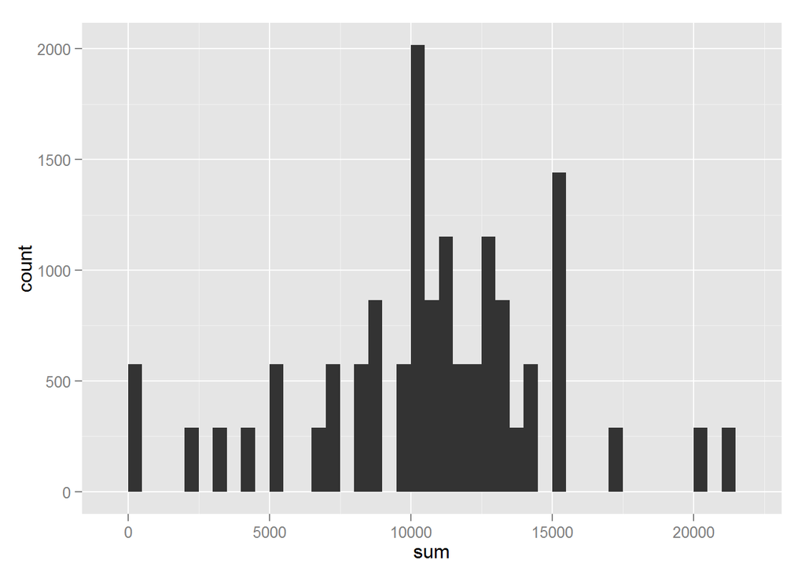

```r
totalSteps <- ddply(data, .(date), mutate, sum=sum(steps))
qplot(sum, data=totalSteps, geom="histogram", binwidth=500)
```

```r
meanSteps <- mean(totalSteps$sum, na.rm=TRUE)
meanSteps
```

```
## [1] 10766.19
```

```r
medianSteps <- median(totalSteps$sum, na.rm=TRUE)
medianSteps
```

```
## [1] 10765
```

## What is the average daily activity pattern?

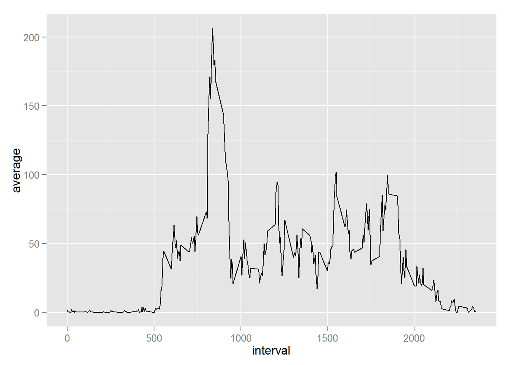

```r
intervalFactor <- as.factor(data$interval)
data[,4] <- intervalFactor
averageSteps <- ddply(data, .(intervalFactor), mutate, average=mean(steps, na.rm=TRUE))
qplot(interval, average, data = averageSteps, geom = "line")
```

```r
intervalMax <- max(averageSteps$average)
intervalMax
```

```
## [1] 206.1698
```

## Imputing missing values and creating a new dataset with the missing values filled in

For replacing NAs, the average across all days was chosen.

```r
numberNA <- sum(is.na(data$steps))
indexNA <- which(is.na(data$steps))
dataSansNA <- data
dataSansNA$steps[indexNA] <- averageSteps$average[indexNA]
```

## Make a histogram of the total number of steps taken each day and Calculate and report the mean and median total number of steps taken per day.

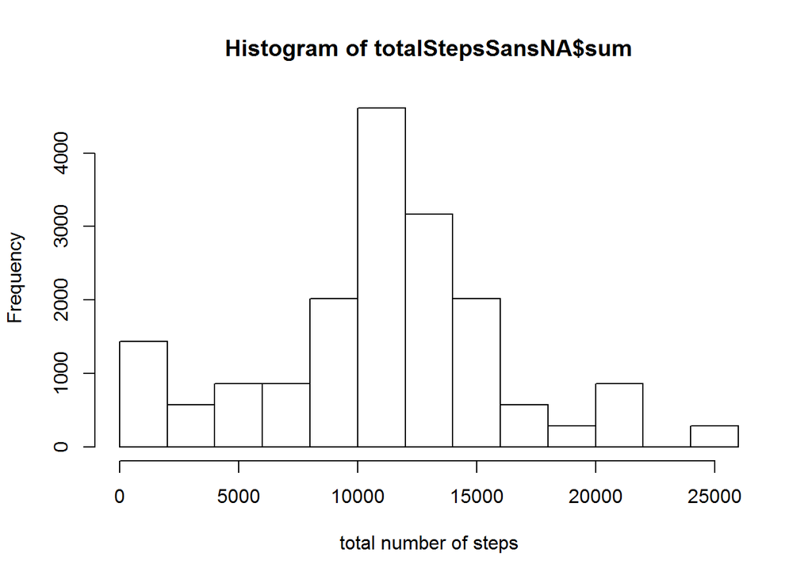

```r
totalStepsSansNA <- ddply(dataSansNA, .(date), mutate, sum=sum(steps))
hist(totalStepsSansNA$sum, xlab = "total number of steps")
```

```r
meanStepsSansNA <- mean(totalStepsSansNA$sum, na.rm=TRUE)
meanStepsSansNA
```

```
## [1] 10889.8
```

```r
medianStepsSansNA <- median(totalStepsSansNA$sum, na.rm=TRUE)
medianStepsSansNA
```

```
## [1] 11015
```

## Are there differences in activity patterns between weekdays and weekends?

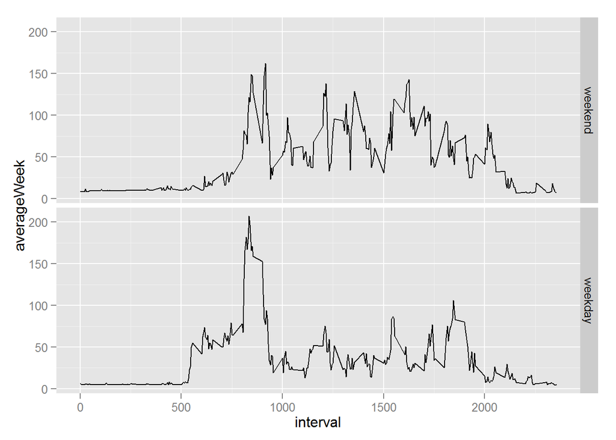

```r
dataSansNA$dateNew <- as.Date(as.character(dataSansNA$date))
days <- weekdays(dataSansNA$dateNew, abbreviate = FALSE)
weekdays <- c("Monday", "Tuesday", "Wednesday", "Thursday", "Friday")
weekend <- c("Saturday", "Sunday")
dataSansNA$daysOfWeek <- factor((weekdays(dataSansNA$dateNew) %in% weekdays), levels=c(FALSE, TRUE), labels=c('weekend', 'weekday'))
dataWeek <- ddply(dataSansNA, .(interval, daysOfWeek), mutate, averageWeek=mean(steps))
qplot(interval,  averageWeek,  data  =  dataWeek,   facets  =   daysOfWeek~., geom="line")
```

During weekends, there seems to be more activity throughout the wh9ole day, while during weekdays activity is centered on specific intervals.